# DATA2004 Refresher

Tidyverse + Quarto Review

Author

Kay Hales

## Before you begin

The goal of this refresher is to practice the R skills you learned in DATA1004 and get more comfortable working in a Quarto document.

This is **not new material**. You should look through your notes and materials from DATA1004 and the R4DS book for this course if you get stuck. And **please** feel free to email me if you want any help at all.

As you work:

1. Write your R code inside code chunks.
2. Write your answers and interpretations as normal text **outside** code chunks.
3. Render your document periodically rather than waiting until the end.
4. Your final document should render successfully to HTML.

Please refer to this [Quarto guide](https://quarto.org/docs/get-started/hello/rstudio.html) for a helpful review of Quarto.

Please refer to Dr. LeVan’s [Book](https://levanjm.github.io/Book-2/) for additional review of R.

You will **not** be graded for this. I realized today it’s been over a year since some of us have worked in R at all, so this is to give you a chance to see what you remember, give you a chance to review, and give you the opportunity to become reacquainted with Quarto. :)

There are gaps before headings for you to put your code chunks and written responses.

## Setup

First, let’s load the packages we need.

You’ll need to run `install.packages(palmerpenguins)` **once** in your console if you haven’t done so before.

```r
library(tidyverse)
library(palmerpenguins)
```

We will use the `penguins` dataset from the `palmerpenguins` package.

```r
penguins <- penguins
glimpse(penguins)
```

```
Rows: 344
Columns: 8
$ species           <fct> Adelie, Adelie, Adelie, Adelie, Adelie, Adelie, Adel…
$ island            <fct> Torgersen, Torgersen, Torgersen, Torgersen, Torgerse…
$ bill_length_mm    <dbl> 39.1, 39.5, 40.3, NA, 36.7, 39.3, 38.9, 39.2, 34.1, …
$ bill_depth_mm     <dbl> 18.7, 17.4, 18.0, NA, 19.3, 20.6, 17.8, 19.6, 18.1, …
$ flipper_length_mm <int> 181, 186, 195, NA, 193, 190, 181, 195, 193, 190, 186…
$ body_mass_g       <int> 3750, 3800, 3250, NA, 3450, 3650, 3625, 4675, 3475, …
$ sex               <fct> male, female, female, NA, female, male, female, male…
$ year              <int> 2007, 2007, 2007, 2007, 2007, 2007, 2007, 2007, 2007…
```

### Getting oriented

Two questions:

1. What are the dimensions of the `penguins` dataset?
2. What does one row of `penguins` seem to represent?

## Getting reacquainted with the basic verbs

### Select

Create an object called `penguins_small` that contains only:

1. species
2. island
3. sex
4. body_mass_g
5. flipper_length_mm

### Filter

Using the original `penguins` dataframe, create a dataframe containing only **Adelie** penguins using `filter().`

Using the original `penguins` dataframe, find all penguins with a body mass greater than **5,000 grams** using `filter`.

And then use `glimpse()` to look at your results for all of the above.

### Creating new variables

Create a new dataframe with a variabled called `body_mass_kg` that converts each penguin’s body mass in kilograms.

```r
penguins_kg <- penguins |>
  mutate(
    body_mass_kg = body_mass_g/1000
  )
```

## Summaries

Let’s say I want you to compare three penguin species, but I don’t tell you which three in my email.

First, find out the different values in `species` and then select any three (since I didn’t think to email you again and left my office) and give me summaries of

1. The number of observations;
2. mean body mass;
3. median body mass;
4. mean flipper length

*note:* some could have missing values. how should you deal with that?

```r
penguins |>
  group_by(species) |>
  summarise(
    n = n(),
    avg_mass = mean(body_mass_g, na.rm = TRUE),
    mean_mass = median(body_mass_g, na.rm = TRUE),
    mean_flip = mean(flipper_length_mm, na.rm = TRUE)
  ) |>
  ungroup()
```

```
# A tibble: 3 × 5
  species       n avg_mass mean_mass mean_flip
  <fct>     <int>    <dbl>     <dbl>     <dbl>
1 Adelie      152    3701.      3700      190.
2 Chinstrap    68    3733.      3700      196.
3 Gentoo      124    5076.      5000      217.
```

## More independent review

From here on, I will tell you the result I want and then it is up to you to figure it out.

### A)

Among **female** penguins, which species has the greatest average body mass?

```r
penguins |>
  filter(sex == "female") |>
  group_by(species) |>
  summarise(
    avg_mass = mean(body_mass_g, na.rm = TRUE)
  ) |>
  arrange(desc(avg_mass))
```

```
# A tibble: 3 × 2
  species   avg_mass
  <fct>        <dbl>
1 Gentoo       4680.
2 Chinstrap    3527.
3 Adelie       3369.
```

### B)

For each species and island combination, determine

1. how many observations are present;
2. mean flipper length

Then arrange the resulting table from **greatest to smallest** mean flipper length

```r
penguins |>
  group_by(species, island) |>
  summarise(
    n = n(),
    avg_flip = mean(flipper_length_mm, na.rm = TRUE)
  ) |>
  ungroup() |>
  arrange(desc(avg_flip))
```

```
`summarise()` has regrouped the output.
ℹ Summaries were computed grouped by species and island.
ℹ Output is grouped by species.
ℹ Use `summarise(.groups = "drop_last")` to silence this message.
ℹ Use `summarise(.by = c(species, island))` for per-operation grouping
  (`?dplyr::dplyr_by`) instead.
```

```
# A tibble: 5 × 4
  species   island        n avg_flip
  <fct>     <fct>     <int>    <dbl>
1 Gentoo    Biscoe      124     217.
2 Chinstrap Dream        68     196.
3 Adelie    Torgersen    52     191.
4 Adelie    Dream        56     190.
5 Adelie    Biscoe       44     189.
```

### C)

Which individual penguins have the five greatest recorded body mass? Your result should contain only:

1. species
2. island
3. sex
4. body mass

```r
penguins |>
  select(
    species, island, sex, body_mass_g
  ) |>
  arrange(desc(body_mass_g)) |>
  slice_head(n = 5)
```

```
# A tibble: 5 × 4
  species island sex   body_mass_g
  <fct>   <fct>  <fct>       <int>
1 Gentoo  Biscoe male         6300
2 Gentoo  Biscoe male         6050
3 Gentoo  Biscoe male         6000
4 Gentoo  Biscoe male         6000
5 Gentoo  Biscoe male         5950
```

## Viz review

1. Create a visualization that compares the **distribution of body mass across species.**
   1. Give your plot a meaningful title and label your axes.

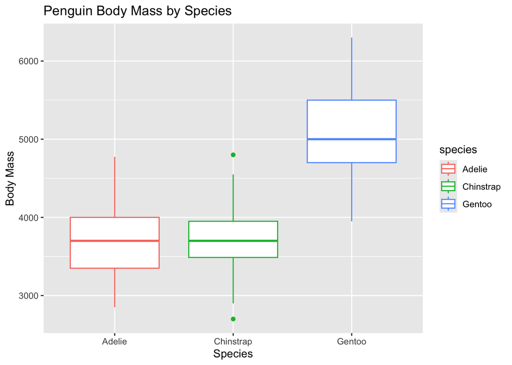

```r
penguins |>
  ggplot(aes(x = species, y = body_mass_g, color = species)) +
  geom_boxplot() +
  labs(title = "Penguin Body Mass by Species",
       x = "Species",
       y = "Body Mass")
```

1. Create a scatterplot showing the relationship between flipper length and body mass.
   1. Create a new scatterplot for this relationship, but differentiate species by any aesthetic of your choosing.
   2. Create a new scatterplot for this relationship, but only include **three** species and then facet to examine the relationship across three species separately.

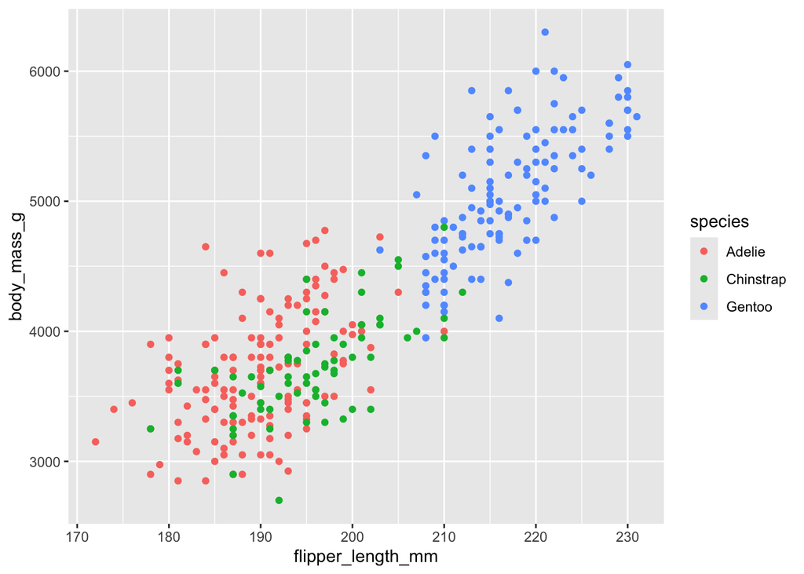

```r
penguins |>
  ggplot(aes(x = flipper_length_mm, y = body_mass_g, color = species)) +
  geom_point()
```

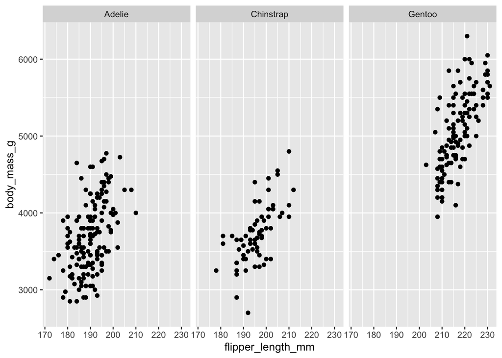

```r
penguins |>
  ggplot(aes(x = flipper_length_mm, y = body_mass_g)) +
  geom_point() +
  facet_wrap(~ species)
```

## Put it together

Hopefully now you’ve done enough of the review to get a completely open-ended question. For your last question, here’s what id like to see

Do male and female penguins appear to differ in body mass, and does that difference look similar across species?

```r
penguins |>
  filter(!is.na(sex)) |>
  group_by(species, sex) |>
  summarise(
    n = n(),
    mean_mass = mean(body_mass_g, na.rm = TRUE)
  ) |>
  ungroup()
```

```
`summarise()` has regrouped the output.
ℹ Summaries were computed grouped by species and sex.
ℹ Output is grouped by species.
ℹ Use `summarise(.groups = "drop_last")` to silence this message.
ℹ Use `summarise(.by = c(species, sex))` for per-operation grouping
  (`?dplyr::dplyr_by`) instead.
```

```
# A tibble: 6 × 4
  species   sex        n mean_mass
  <fct>     <fct>  <int>     <dbl>
1 Adelie    female    73     3369.
2 Adelie    male      73     4043.
3 Chinstrap female    34     3527.
4 Chinstrap male      34     3939.
5 Gentoo    female    58     4680.
6 Gentoo    male      61     5485.
```

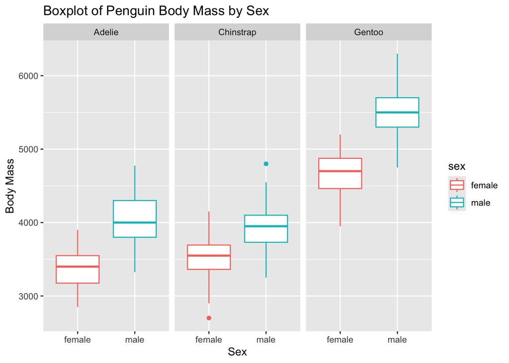

```r
penguins |>
  filter(!is.na(sex)) |>
  ggplot(aes(x = sex, y = body_mass_g, color = sex)) +
  geom_boxplot() +
  facet_wrap(~ species) +
  labs(title = "Boxplot of Penguin Body Mass by Sex",
       x = "Sex",
       y = "Body Mass")
```